# Quick Project 1

Josh Wolfe

07/08/2021

# 1 Load Libraries

```r
# Load packages
library(tidyverse)
library(ggplot2)
library(gridExtra)
library(scales)
library(vtable)
library(patchwork)
library(GGally)
library(janitor)
library(choroplethrZip)
library(choroplethr)
```

# 2 Load and Transform Data

```r
# Load data
df <- read.csv("qp1_data.csv")

# Transform Numerical variables to factor
df[,'waterfront'] <- factor(df[,'waterfront'])
df[,'view'] <- factor(df[,'view'])
df[,'condition'] <- factor(df[,'condition'])
df[,'yr_built'] <- factor(df[,'yr_built'])
df[,'yr_renovated'] <- factor(df[,'yr_renovated'])
df[,'zip_code'] <- factor(df[,'zip_code'])
df[,'grade'] <- factor(df[,'grade'])
```

# 3 Base EDA Step 1: Uni-variate non-graphical EDA

```r
# Look at the top few rows of the data
head(df)
```

```
##     price bedrooms bathrooms sqft_living sqft_lot floors waterfront view grade
## 1  221900        3      1.00        1180     5650      1          0    0     7
## 2  538000        3      2.25        2570     7242      2          0    0     7
## 3  180000        2      1.00         770    10000      1          0    0     6
## 4  604000        4      3.00        1960     5000      1          0    0     7
## 5  510000        3      2.00        1680     8080      1          0    0     8
## 6 1230000        4      4.50        5420   101930      1          0    0    11
##   condition yr_built yr_renovated zip_code
## 1         3     1955            0    98178
## 2         3     1951         1991    98125
## 3         3     1933            0    98028
## 4         5     1965            0    98136
## 5         3     1987            0    98074
## 6         3     2001            0    98053
```

- Data appears to be tidy
  - Each column is of the same variable type and has a unique entry for each row.

```r
# Get a breakdown of the variables
str(df)
```

```
## 'data.frame':    21613 obs. of  13 variables:
##  $ price       : num  221900 538000 180000 604000 510000 ...
##  $ bedrooms    : int  3 3 2 4 3 4 3 3 3 3 ...
##  $ bathrooms   : num  1 2.25 1 3 2 4.5 2.25 1.5 1 2.5 ...
##  $ sqft_living : int  1180 2570 770 1960 1680 5420 1715 1060 1780 1890 ...
##  $ sqft_lot    : int  5650 7242 10000 5000 8080 101930 6819 9711 7470 6560 ...
##  $ floors      : num  1 2 1 1 1 1 2 1 1 2 ...
##  $ waterfront  : Factor w/ 2 levels "0","1": 1 1 1 1 1 1 1 1 1 1 ...
##  $ view        : Factor w/ 5 levels "0","1","2","3",..: 1 1 1 1 1 1 1 1 1 1 ...
##  $ grade       : Factor w/ 12 levels "1","3","4","5",..: 6 6 5 6 7 10 6 6 6 6 ...
##  $ condition   : Factor w/ 5 levels "1","2","3","4",..: 3 3 3 5 3 3 3 3 3 3 ...
##  $ yr_built    : Factor w/ 116 levels "1900","1901",..: 56 52 34 66 88 102 96 64 61 104 ...
##  $ yr_renovated: Factor w/ 70 levels "0","1934","1940",..: 1 46 1 1 1 1 1 1 1 1 ...
##  $ zip_code    : Factor w/ 70 levels "98001","98002",..: 67 56 17 59 38 30 3 69 61 24 ...
```

```r
# Get a breakdown of the variables
vtable(df)
```

df

| Name | Class | Values |
| --- | --- | --- |
| price | numeric | Num: 75000 to 7700000 |
| bedrooms | integer | Num: 0 to 33 |
| bathrooms | numeric | Num: 0 to 8 |
| sqft_living | integer | Num: 290 to 13540 |
| sqft_lot | integer | Num: 520 to 1651359 |
| floors | numeric | Num: 1 to 3.5 |
| waterfront | factor | ‘0’ ‘1’ |
| view | factor | ‘0’ ‘1’ ‘2’ ‘3’ ‘4’ |
| grade | factor | ‘1’ ‘3’ ‘4’ ‘5’ ‘6’ and more |
| condition | factor | ‘1’ ‘2’ ‘3’ ‘4’ ‘5’ |
| yr_built | factor | ‘1900’ ‘1901’ ‘1902’ ‘1903’ ‘1904’ and more |
| yr_renovated | factor | ‘0’ ‘1934’ ‘1940’ ‘1944’ ‘1945’ and more |
| zip_code | factor | ‘98001’ ‘98002’ ‘98003’ ‘98004’ ‘98005’ and more |

- Three Numeric variables
- Three integer variables
- Seven factor variables
  - Waterfront is a binary variable where 0 is no and 1 is yes
  - View, Grade, and Condition are rankings
  - Yr_built and Yr_renovated are years property was built and renovated
  - Zip Code is the property zip code

```r
# Get variable descriptive statistics
summary(df)
```

```
##      price            bedrooms        bathrooms      sqft_living
##  Min.   :  75000   Min.   : 0.000   Min.   :0.000   Min.   :  290
##  1st Qu.: 321950   1st Qu.: 3.000   1st Qu.:1.750   1st Qu.: 1427
##  Median : 450000   Median : 3.000   Median :2.250   Median : 1910
##  Mean   : 540182   Mean   : 3.371   Mean   :2.115   Mean   : 2080
##  3rd Qu.: 645000   3rd Qu.: 4.000   3rd Qu.:2.500   3rd Qu.: 2550
##  Max.   :7700000   Max.   :33.000   Max.   :8.000   Max.   :13540
##
##     sqft_lot           floors      waterfront view          grade
##  Min.   :    520   Min.   :1.000   0:21450    0:19489   7      :8981
##  1st Qu.:   5040   1st Qu.:1.000   1:  163    1:  332   8      :6068
##  Median :   7618   Median :1.500              2:  963   9      :2615
##  Mean   :  15107   Mean   :1.494              3:  510   6      :2038
##  3rd Qu.:  10688   3rd Qu.:2.000              4:  319   10     :1134
##  Max.   :1651359   Max.   :3.500                        11     : 399
##                                                         (Other): 378
##  condition    yr_built      yr_renovated      zip_code
##  1:   30   2014   :  559   0      :20699   98103  :  602
##  2:  172   2006   :  454   2014   :   91   98038  :  590
##  3:14031   2005   :  450   2013   :   37   98115  :  583
##  4: 5679   2004   :  433   2003   :   36   98052  :  574
##  5: 1701   2003   :  422   2000   :   35   98117  :  553
##            1977   :  417   2005   :   35   98042  :  548
##            (Other):18878   (Other):  680   (Other):18163
```

- Comments and questions about the data
  - The median property value is $450,000 while the mean is $540,182
  - Property values are positivley skewed likely due to high value outliers
  - Bedrooms are also positivley skewed with a median of 3 but mean of 3.4
  - There is a maximum of 33 bedrooms
  - Interestingly bathrooms are slightly negatively skewed with a median of 2.25 and mean of 2.1
  - Living space and lot size are also positviely skewed
  - Median/mean floor count is 1.5 with a max of 3.5 floors
  - A majority of properties has no waterfront or view
  - Do properties with a waterfront or view cost more
  - Do properties with views cost more than those with waterfronts
  - Are waterfront properties considered to have a view
  - Most properties are condition 3, which may be average condition
  - Most properties have not be renovated

## 3.1 Potential research questions

- How are different property values associated with price
  - Square footage of living space or property, floor count, grade, condition, etc
- What does valuation look like from a zip code perspective
- What does waterfront and view do to valuation

# 4 Base EDA Step 2: Uni-variate graphical EDA

## 4.1 Values

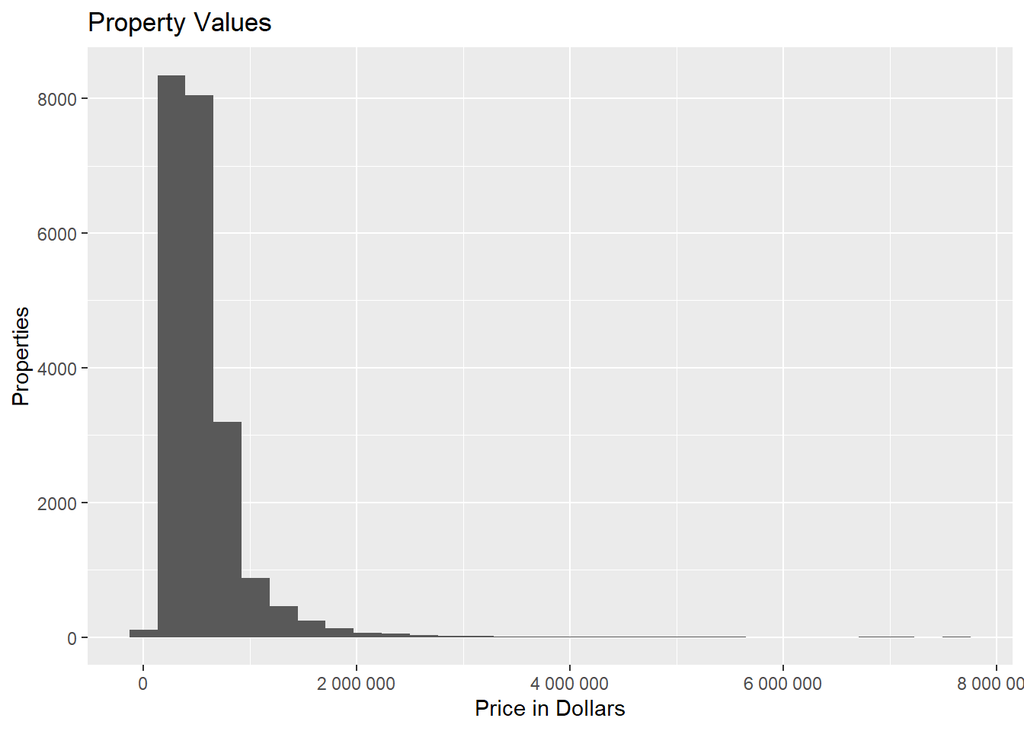

```r
# Create histogram for price
values <- ggplot(data = df, mapping = aes(x = price)) +
  geom_histogram() +
  labs(title = "Property Values", x = "Price in Dollars",
       y = "Properties") +
  scale_x_continuous(labels = label_number())

values
```

+ Histogram for values show the long right hand side tail

```
- shows median is the appropriate statistic to use
- Skews are due to high value homes
```

## 4.2 Home Features

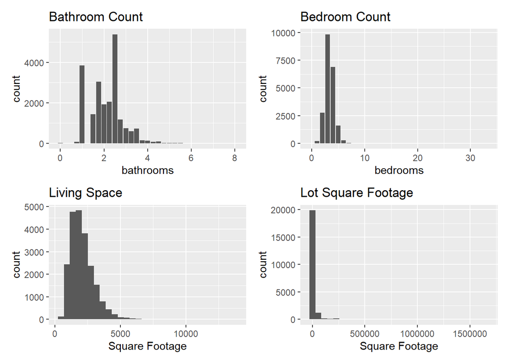

```r
# Create four graph graphics of bedrooms, bathrooms, living and lot squarefootage
bedrooms <- ggplot(data = df, mapping = aes(x = bedrooms)) +
  geom_bar() +
  labs(title = "Bedroom Count", x = "bedrooms",
       y = "count")

bathrooms <- ggplot(data = df, mapping = aes(x = bathrooms)) +
  geom_bar() +
  labs(title = "Bathroom Count", x = "bathrooms",
       y = "count")

sqft_lv <- ggplot(data = df, mapping = aes(x = sqft_living)) +
  geom_histogram() +
  labs(title = "Living Space", x = "Square Footage",
       y = "count")

sqft_p <- ggplot(data = df, mapping = aes(x = sqft_lot)) +
  geom_histogram() +
  labs(title = "Lot Square Footage", x = "Square Footage",
       y = "count")

(bathrooms + bedrooms) / (sqft_lv + sqft_p)
```

- Bar chars show positive skews due to large homes
  - shows median is the appropriate statistic to use for feature values

## 4.3 Property details

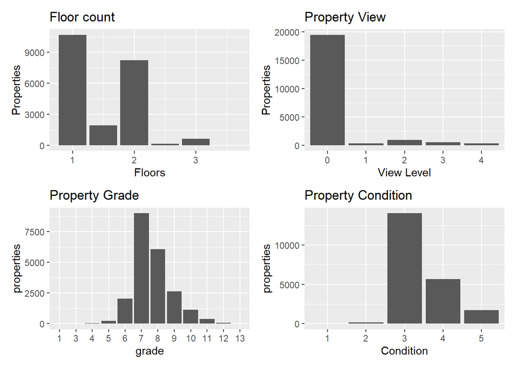

```r
# Generate four graph graphic of property details
floors <- ggplot(data = df, mapping = aes(x = floors)) +
  geom_bar() +
  labs(title = "Floor count", x = "Floors",
       y = "Properties")

condition <- ggplot(data = df, mapping = aes(x = condition)) +
  geom_bar() +
  labs(title = "Property Condition", x = "Condition",
       y = "properties")

grade <- ggplot(data = df, mapping = aes(x = grade)) +
  geom_bar() +
  labs(title = "Property Grade", x = "grade",
       y = "properties")

view <- ggplot(data = df, mapping = aes(x = view)) +
  geom_bar() +
  labs(title = "Property View", x = "View Level",
       y = "Properties")

(floors + view) / (grade + condition)
```

## 4.4 Property Details Continued

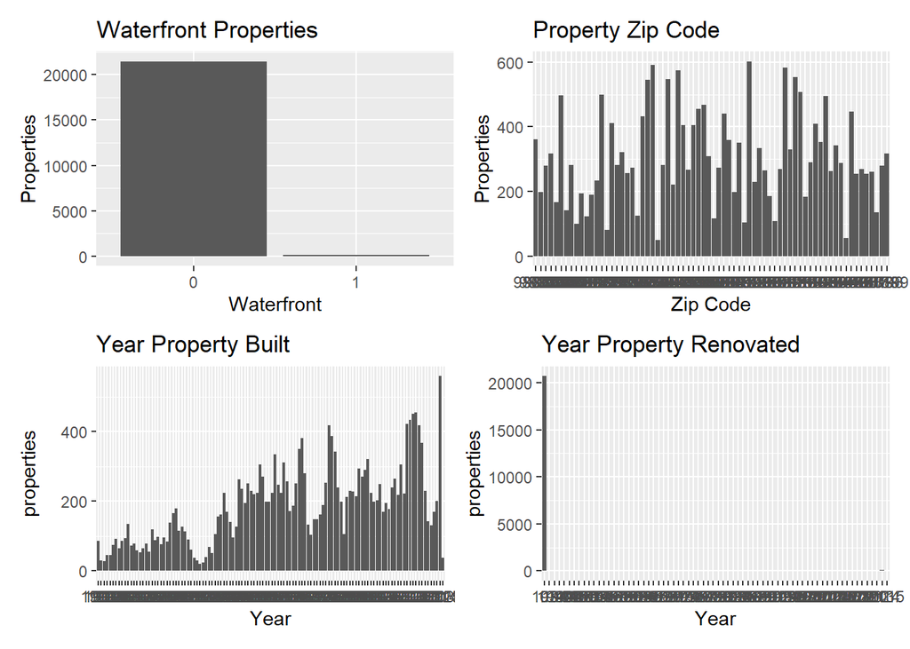

```r
# Continue previous graphic with remaining variables
waterfront <- ggplot(data = df, mapping = aes(x = waterfront)) +
  geom_bar() +
  labs(title = "Waterfront Properties", x = "Waterfront",
       y = "Properties")

yr_built <- ggplot(data = df, mapping = aes(x = yr_built)) +
  geom_bar() +
  labs(title = "Year Property Built", x = "Year",
       y = "properties")

yr_renovated <- ggplot(data = df, mapping = aes(x = yr_renovated)) +
  geom_bar() +
  labs(title = "Year Property Renovated", x = "Year",
       y = "properties")

zip <- ggplot(data = df, mapping = aes(x = zip_code)) +
  geom_bar() +
  labs(title = "Property Zip Code", x = "Zip Code",
       y = "Properties")

(waterfront + zip) / (yr_built + yr_renovated)
```

# 5 Base EDA Step 3: Multi-variate non-graphical EDA

```r
# Look at correlational data of quantitative variables
num_corr <- df %>%
  select_if(is.numeric) %>%
  cor() %>%
  round(2) %>%
  kable()

num_corr
```

|  | price | bedrooms | bathrooms | sqft_living | sqft_lot | floors |
| --- | --- | --- | --- | --- | --- | --- |
| price | 1.00 | 0.31 | 0.53 | 0.70 | 0.09 | 0.26 |
| bedrooms | 0.31 | 1.00 | 0.52 | 0.58 | 0.03 | 0.18 |
| bathrooms | 0.53 | 0.52 | 1.00 | 0.75 | 0.09 | 0.50 |
| sqft_living | 0.70 | 0.58 | 0.75 | 1.00 | 0.17 | 0.35 |
| sqft_lot | 0.09 | 0.03 | 0.09 | 0.17 | 1.00 | -0.01 |
| floors | 0.26 | 0.18 | 0.50 | 0.35 | -0.01 | 1.00 |

- Living square footage has the highest positive correlation with price at 0.7. This is followed by bathrooms are 0.53
  - Interestingly bathrooms are more positivley correlated with living square footage than bedroom count
  - Lot size has very little correlation with price

```r
# Examine the overlap of waterfront properties and properties with views
df %>%
  tabyl(view, waterfront) %>%
  adorn_totals(where = c("row", "col")) %>%
  kable()
```

| view | 0 | 1 | Total |
| --- | --- | --- | --- |
| 0 | 19489 | 0 | 19489 |
| 1 | 331 | 1 | 332 |
| 2 | 955 | 8 | 963 |
| 3 | 491 | 19 | 510 |
| 4 | 184 | 135 | 319 |
| Total | 21450 | 163 | 21613 |

- Most Waterfront homes have a view ranked 4
  - Do waterfront and view property’s values reflect this?

# 6 Base EDA Step 4: Multi-variate graphical EDA

## 6.1 Categorical Variables

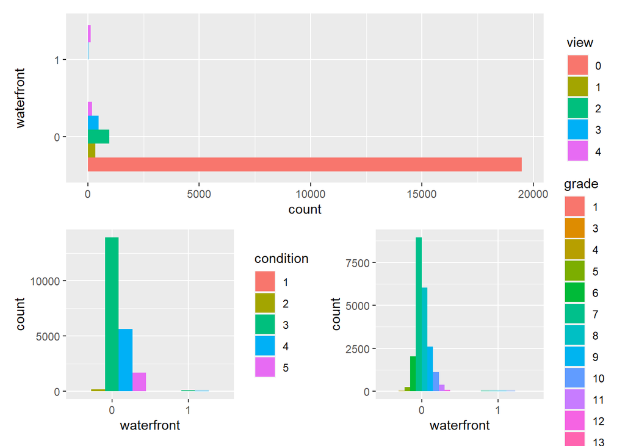

```r
# Examine waterfront property information
wv <- df %>%
    ggplot(mapping = aes(x = waterfront, fill = view)) +
    geom_bar(position = "dodge") +
    coord_flip()

wc <- df %>%
    ggplot(mapping = aes(x = waterfront, fill = condition)) +
    geom_bar(position = "dodge")

wg <- df %>%
    ggplot(mapping = aes(x = waterfront, fill = grade)) +
    geom_bar(position = "dodge")

wv / (wc + wg)
```

- Waterfront properties are a ver small portion of overall sales

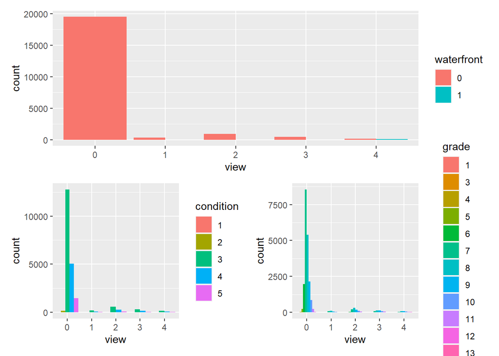

```r
# Examine
vw <- df %>%
    ggplot(mapping = aes(fill = waterfront, y = view)) +
    geom_bar(position = "dodge") +
    coord_flip()

vc <- df %>%
    ggplot(mapping = aes(x = view, fill = condition)) +
    geom_bar(position = "dodge")

vg <- df %>%
    ggplot(mapping = aes(x = view, fill = grade)) +
    geom_bar(position = "dodge")

vw / (vc + vg)
```

- Properties with views are a small portion of overall sales
  - Properties with views are usually found with condition 3 and grade 7+

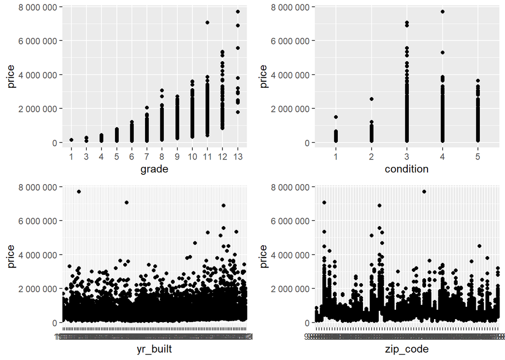

```r
# Look at condition and
grid.arrange(

df %>%
  ggplot(mapping = aes(x = grade, y = price)) +
  geom_point() +
  scale_y_continuous(labels = label_number()),

df %>%
  ggplot(mapping = aes(x = condition, y = price)) +
  geom_point() +
  scale_y_continuous(labels = label_number()),

df %>%
  ggplot(mapping = aes(x = yr_built, y = price)) +
  geom_point() +
  scale_y_continuous(labels = label_number()),

df %>%
  ggplot(mapping = aes(x = zip_code, y = price)) +
  geom_point() +
  scale_y_continuous(labels = label_number())

)
```

- Grade is also positively correlated while condition interestingly follows and inverted U, with condition 3 and 4 being high value homes
  - I wonder where the disconnect is for condition 5 homes and why the high value homes are not in that catagory
  - High value homes seem to be spread out among multiple zip codes and years built

```r
df %>%
  group_by(zip_code) %>%
  summarize(median = median(price))
```

```
## # A tibble: 70 x 2
##    zip_code   median
##    <fct>       <dbl>
##  1 98001     260000
##  2 98002     235000
##  3 98003     267475
##  4 98004    1150000
##  5 98005     765475
##  6 98006     760184.
##  7 98007     555000
##  8 98008     545000
##  9 98010     360000.
## 10 98011     470000
## # ... with 60 more rows
```

- 98039 (Medina) has the highest median property value ($1,895,000) while 98168 (Skyway) and 98002 (Auburn) are tied for lowest ($235,000)

## 6.2 Quantitative Variables

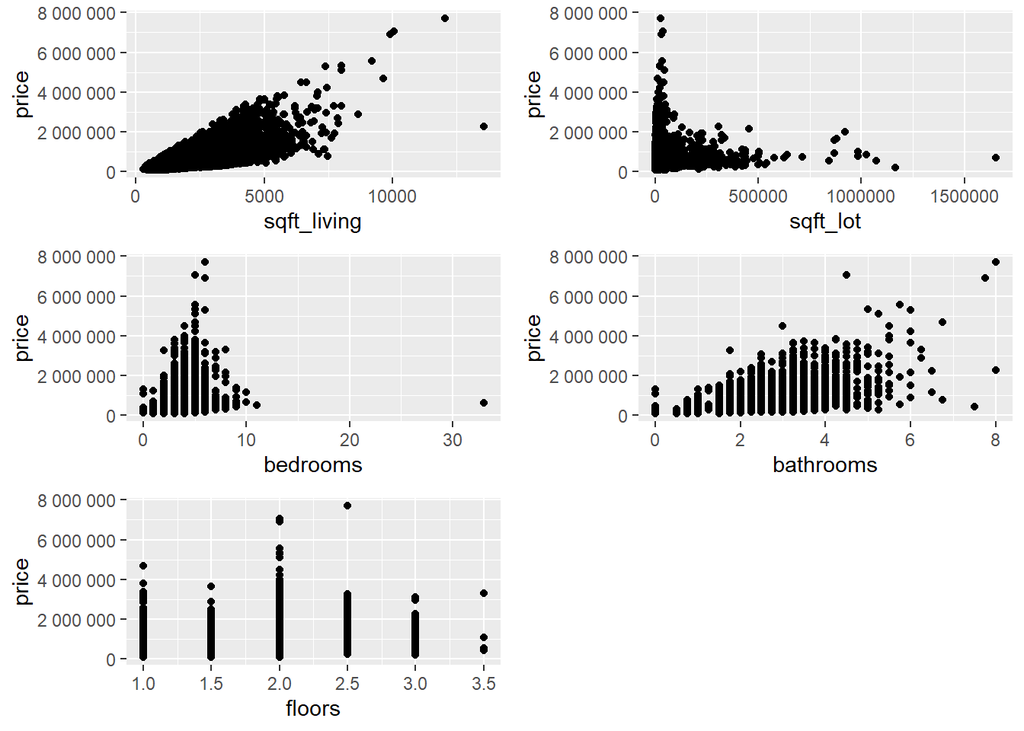

```r
grid.arrange(

df %>%
  ggplot(mapping = aes(x = sqft_living, y = price)) +
  geom_point() +
  scale_y_continuous(labels = label_number()),

df %>%
  ggplot(mapping = aes(x = sqft_lot, y = price)) +
  geom_point() +
  scale_y_continuous(labels = label_number()),

df %>%
  ggplot(mapping = aes(x = bedrooms, y = price)) +
  geom_point() +
  scale_y_continuous(labels = label_number()),

df %>%
  ggplot(mapping = aes(x = bathrooms, y = price)) +
  geom_point() +
  scale_y_continuous(labels = label_number()),

df %>%
  ggplot(mapping = aes(x = floors, y = price)) +
  geom_point() +
  scale_y_continuous(labels = label_number())

)
```

# 7 Detailed EDA: Questions Raised in Base EDA

## 7.1 How do waterfront property values compare to non-waterfront?

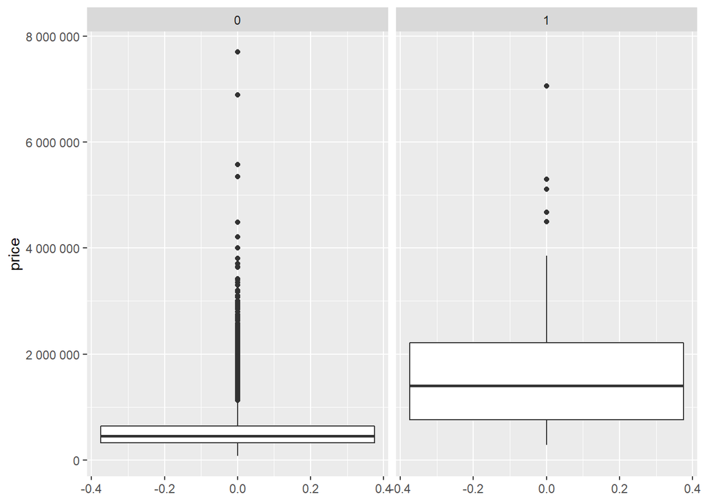

```r
# research question code
# faceted graph

df %>%
  ggplot(mapping = aes(x = price)) +
  geom_boxplot() +
  coord_flip() +
  scale_x_continuous(labels = label_number()) +
  facet_wrap( ~ waterfront)
```

```r
# Get median property values
df %>%
  group_by(waterfront) %>%
  summarize(median = median(price))
```

```
## # A tibble: 2 x 2
##   waterfront  median
##   <fct>        <dbl>
## 1 0           450000
## 2 1          1400000
```

- Here we can see that the average values for waterfront properties is higher than non-waterfront
  - The median price for waterfront properties is $1,400,000 while non-waterfront is $450,000

## 7.2 How does the value of properties with views compare to non-view properties?

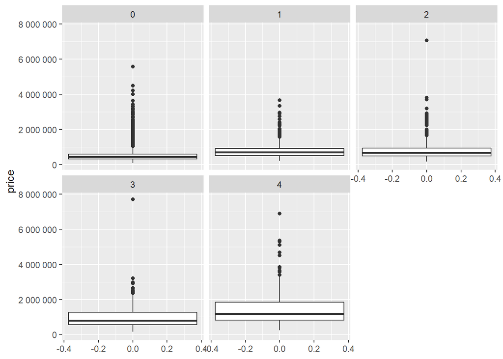

```r
df %>%
  ggplot(mapping = aes(x = price)) +
  geom_boxplot() +
  coord_flip() +
  scale_x_continuous(labels = label_number()) +
  facet_wrap( ~ view)
```

```r
# Get median property values
df %>%
  group_by(view) %>%
  summarize(median = median(price))
```

```
## # A tibble: 5 x 2
##   view   median
##   <fct>   <dbl>
## 1 0      432500
## 2 1      690944
## 3 2      675000
## 4 3      802500
## 5 4     1190000
```

## 7.3 What does the overall valuation breakdown of the area look like?

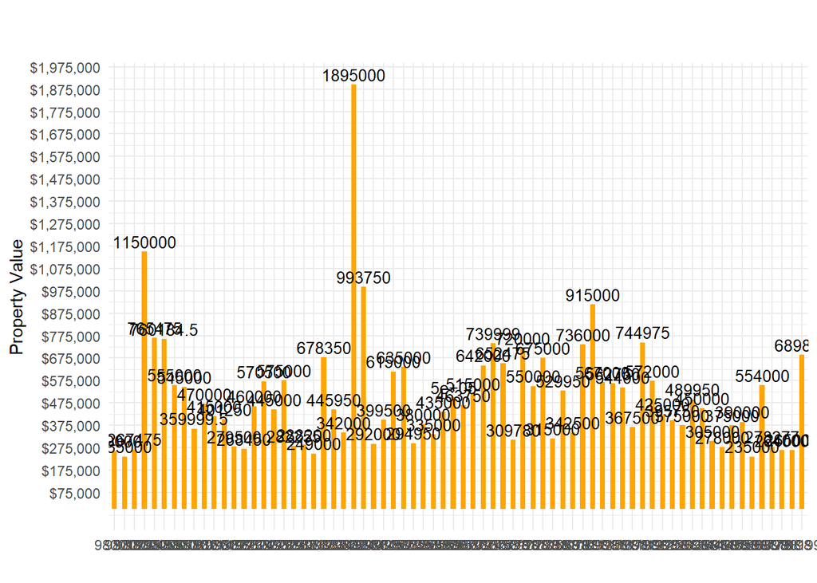

```r
final_zip <- df %>%
  group_by(zip_code) %>%
  summarise(zme = median(price)) %>%
  ggplot(aes(x = zip_code, y = zme)) +
  geom_bar(stat = "identity", fill = "orange", width = 0.5) +
  scale_y_continuous(breaks = round(seq(min(df$price), max(df$price), by = 100000),1),
                     labels = scales::dollar_format())+
  geom_text(aes(label=zme), vjust=-0.3, size=3.5)+
  theme_minimal()+
  ggtitle("",
          sub = "") +
  labs(x = "", y = "Property Value")

final_zip
```

# 8 Summary

# 9 Create and Save Professional Quality Visual

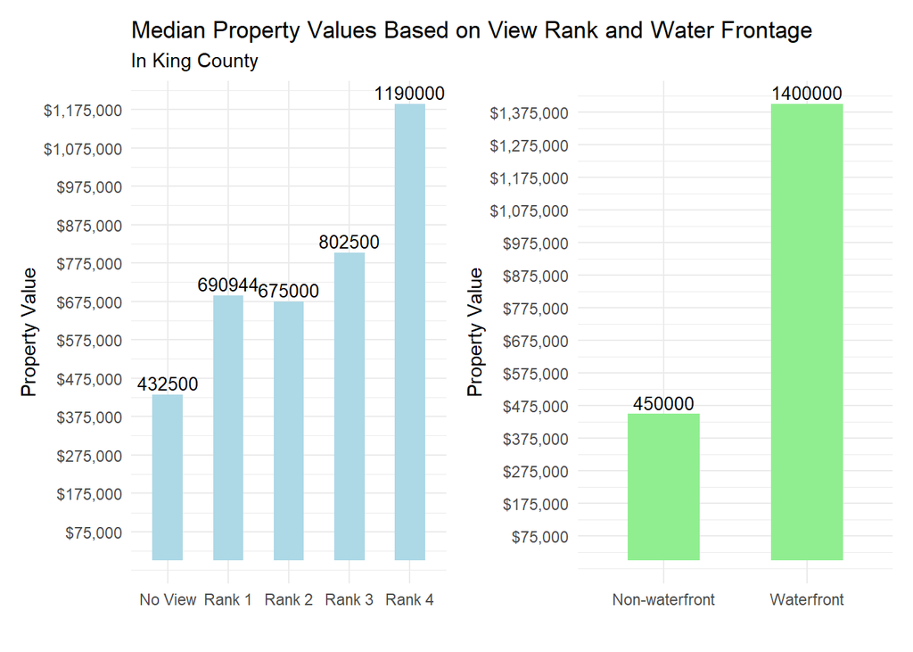

```r
# Waterfront

final_waterfront <- df %>%
  group_by(waterfront) %>%
  summarise(wme = median(price)) %>%
  ggplot(aes(x = waterfront, y = wme)) +
  geom_bar(stat = "identity", fill = "light green", width = 0.5) +
  scale_y_continuous(breaks = round(seq(min(df$price), max(df$price), by = 100000),1),
                     labels = scales::dollar_format())+
  geom_text(aes(label=wme), vjust=-0.3, size=3.5)+
  theme_minimal()+
  ggtitle("",
          sub = "") +
  labs(x = "", y = "Property Value") +
  scale_x_discrete(labels=c("0" = "Non-waterfront", "1" = "Waterfront"))

ggsave(filename = "final_waterfront.png", plot = final_waterfront)
# View
final_view <- df %>%
  group_by(view) %>%
  summarise(vme = median(price)) %>%
  ggplot(aes(x = view, y = vme)) +
  geom_bar(stat = "identity", fill = "light blue", width = 0.5) +
  scale_y_continuous(breaks = round(seq(min(df$price), max(df$price), by = 100000),1),
                     labels = scales::dollar_format())+
  geom_text(aes(label=vme), vjust=-0.3, size=3.5)+
  theme_minimal()+
  ggtitle("Median Property Values Based on View Rank and Water Frontage",
          sub = "In King County") +
  labs(x = "", y = "Property Value") +
  scale_x_discrete(labels=c("0" = "No View", "1" = "Rank 1", "2" = "Rank 2",

                            "3" = "Rank 3", "4" = "Rank 4"))

final_view_waterfront <- final_view + final_waterfront

ggsave(filename = "final_view_waterfront.png", plot = final_view_waterfront)
final_view_waterfront
```

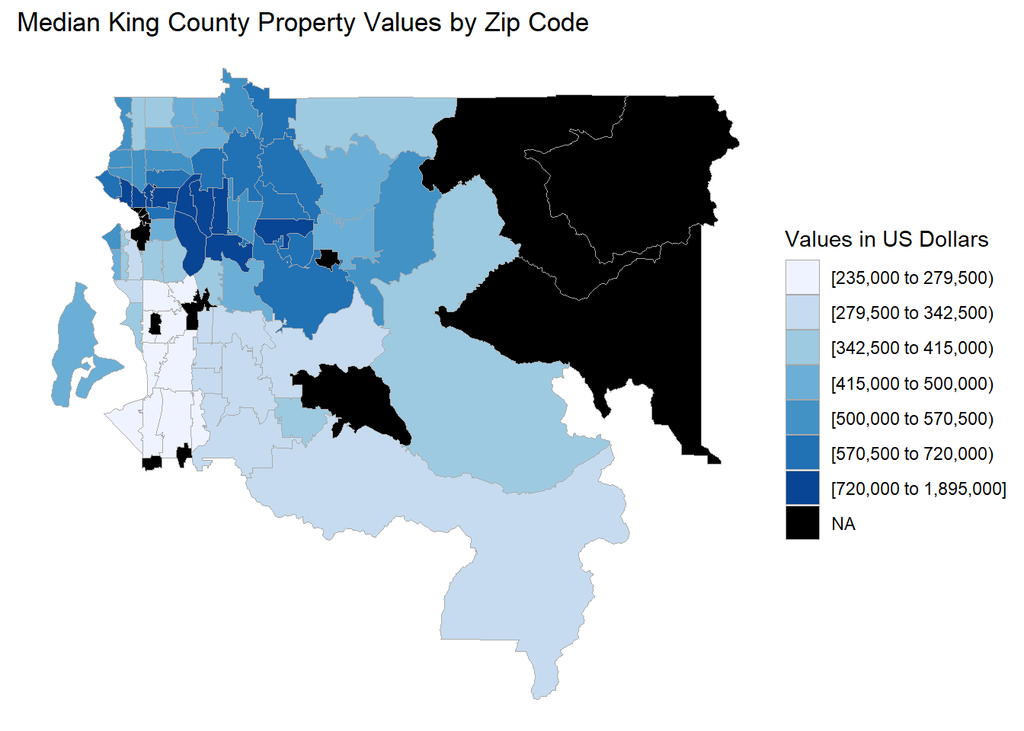

```r
# Create Zip Map
zip_values <- df %>%
  group_by(zip_code) %>%
  summarise(zme = median(price))
colnames(zip_values) <- c("region", "value")
zip_values$region <- as.character(zip_values$region)

kc_fips <- 53033

data(zip.regions)
data(zip_values)
final_zip <- zip_choropleth(zip_values,
               county_zoom = kc_fips,
               title      = "Median King County Property Values by Zip Code",
               legend     = "Values in US Dollars")
ggsave(filename = "final_zip.png", plot = final_zip)
final_zip
```

# 10 Statistical EDA

```r
library(Hmisc)
library(MultinomialCI)
library(htmlTable)
```

The steps of inference are: Gather a representative sample from a population Establish the null/alternative hypothesis (the research question) Set confidence level 1−α to balance Type I & II errors α is the risk level Test the hypothesis for practical and statistical significance based on the sample practical significance: How big is the impact or difference of the variable(s)? statistical significance: How consistent or reliable is the difference? State the results

## 10.1 View Rank

- Null: View has no influence on property value
  - True null: view rank does not impact value
  - False null: view rank does impact sales
  - Type 1: reject true null - ask more for property based on view (inepensive, if expensive use small alpha)
  - Type 2: fail to reject false null - don’t consider view in appraisal (expensive, use large alpha)

Alternative: View has an influence on property value

```r
vchi <- chisq.test(df$view, df$price)
vchi
```

```
##
##  Pearson's Chi-squared test
##
## data:  df$view and df$price
## X-squared = 17162, df = 14496, p-value < 2.2e-16
```

### 10.1.1 Practical Significance

```r
summary(df$view)
```

```
##     0     1     2     3     4
## 19489   332   963   510   319
```

There are fewer properties with views than non-view properties. The small sample size may not be practically or significantly significant

### 10.1.2 Statistical Significance

The property values are statistically different in relation to view rank with a P value of less than 0.001. Therefore we reject the null hypothesis that property values are not related to view

Non-technical: A properties view ranking has an impact on the property’s value Technical: Property values are statistically different for different view ranks with a P value of less than 0.001

## 10.2 Waterfrontage

- Null: Water frontage has no influence on property value Alternative: Water frontage has an influence on property value
  - True null: water frontage does not impact value
  - False null: waterfrontage does impact sales
  - Type 1: reject true null - ask more for property based on water frontage (inepensive, if expensive use small alpha)
  - Type 2: fail to reject false null - don’t consider water frontage in appraisal (expensive, use large alpha)

Alternative: Water frontage has an influence on property value

```r
wchi <- chisq.test(df$waterfront, df$price)
wchi
```

```
##
##  Pearson's Chi-squared test
##
## data:  df$waterfront and df$price
## X-squared = 5953, df = 3624, p-value < 2.2e-16
```

### 10.2.1 Practical Significance

```r
summary(df$waterfront)
```

```
##     0     1
## 21450   163
```

There are only 163 waterfront sales out of 21613 total sales. The sample size is too small to be practically significant

### 10.2.2 Statistical Significance

Waterfront property values are statistically different from non-waterfront with a p value of less than 0.001. We reject the null hypothesis that waterfront does not influence property value.

Non-technical: Water frontage has an impact on property value Technical: Water front property values are statistically different with a P value of less then 0.001